# Climate Change Effects

To define temperature anomalies you need to have a reference, or base, period which NASA clearly states that it is the period between 1951-1980.

```r
weather <-
  read_csv("https://data.giss.nasa.gov/gistemp/tabledata_v3/NH.Ts+dSST.csv",
           skip = 1,
           na = "***")
```

Notice that, when using this function, we added two options: `skip` and `na`.

1. The `skip=1` option is there as the real data table only starts in Row 2, so we need to skip one row.
2. `na = "***"` option informs R how missing observations in the spreadsheet are coded. When looking at the spreadsheet, you can see that missing data is coded as "***". It is best to specify this here, as otherwise some of the data is not recognized as numeric data.

Once the data is loaded, notice that there is a object titled `weather` in the `Environment` panel. If you cannot see the panel (usually on the top-right), go to `Tools` > `Global Options` > `Pane Layout` and tick the checkbox next to `Environment`. Click on the `weather` object, and the dataframe will pop up on a seperate tab. Inspect the dataframe.

For each month and year, the dataframe shows the deviation of temperature from the normal (expected). Further the dataframe is in wide format.

```r
tidyweather <- weather %>% select(Year, Jan, Feb, Mar, Apr, May, Jun, Jul, Aug, Sep, Oct, Nov, Dec)
```

```r
tidyweather <- weather %>%
  select(Year, Jan, Feb, Mar, Apr, May, Jun, Jul, Aug, Sep, Oct, Nov, Dec) %>%
  gather("Jan", "Feb", "Mar","Apr","May","Jun","Jul","Aug","Sep","Oct","Nov","Dec", key = Month, value = delta)
```

## Plotting Information

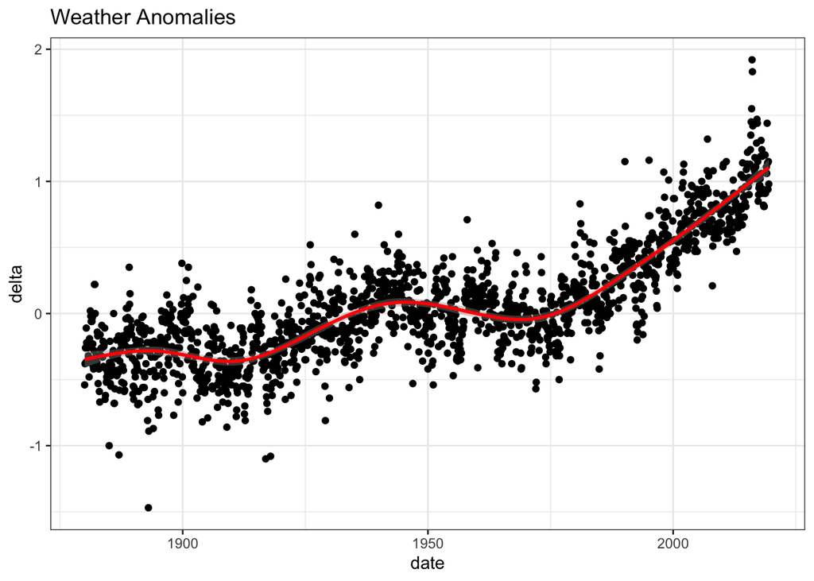

[figure not shown]

```r
tidyweather <- tidyweather %>%
  mutate(date = ymd(paste(as.character(Year), Month, "1")),
         month = month(date, label=TRUE),
         year = year(date))

ggplot(tidyweather, aes(x=date, y = delta))+
  geom_point()+
  geom_smooth(color="red") +
  theme_bw() +
  labs (
    title = "Weather Anomalies"
  )
```

```r
comparison <- tidyweather %>%
  filter(Year>= 1881) %>%     #remove years prior to 1881
  #create new variable 'interval', and assign values based on criteria below:
  mutate(interval = case_when(
    Year %in% c(1881:1920) ~ "1881-1920",
    Year %in% c(1921:1950) ~ "1921-1950",
    Year %in% c(1951:1980) ~ "1951-1980",
    Year %in% c(1981:2010) ~ "1981-2010",
    TRUE ~ "2011-present"
  ))
```

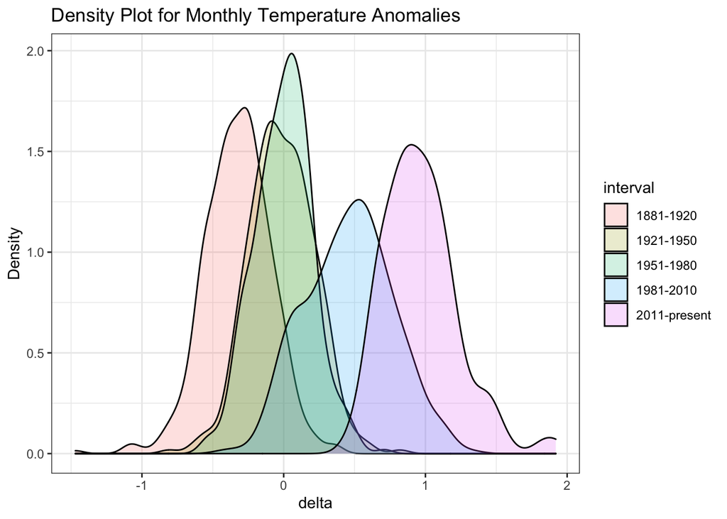

```r
ggplot(comparison, aes(x=delta, fill=interval))+
  geom_density(alpha=0.2) +   #density plot with tranparency set to 20%
  theme_bw() +                #theme
  labs (
    title = "Density Plot for Monthly Temperature Anomalies",
    y     = "Density"         #changing y-axis label to sentence case
  )
```

```r
#creating yearly averages
average_annual_anomaly <- tidyweather %>%
  group_by(Year) %>%   #grouping data by Year

  # creating summaries for mean delta
  # use `na.rm=TRUE` to eliminate NA (not available) values
  summarise(annual_average_delta = mean(delta, na.rm=TRUE))
```

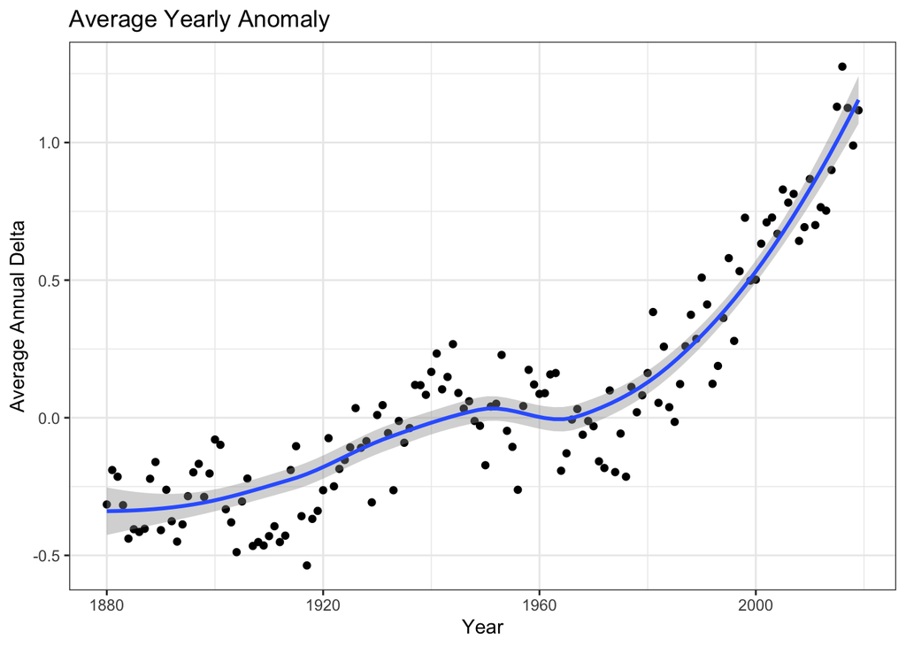

```r
#plotting the data:
ggplot(average_annual_anomaly, aes(x=Year, y= annual_average_delta))+
  geom_point()+

  #Fit the best fit line, using LOESS method
  geom_smooth() +

  #change to theme_bw() to have white background + black frame around plot
  theme_bw() +
  labs (
    title = "Average Yearly Anomaly",
    y     = "Average Annual Delta"
  )
```

## Confidence Interval for `delta`

```r
formula_ci <- comparison %>%
  filter(interval == "2011-present") %>%
  group_by(year) %>%
  summarise(mean_delta = mean(delta, na.rm = TRUE), sd_delta = sd(delta, na.rm = TRUE), count = n(), t_critical = qt(0.975, count-1), se = sd_delta/sqrt(count), margin_of_error = t_critical * se, ci_low = mean_delta - margin_of_error, ci_high = mean_delta + margin_of_error)
formula_ci
```

```
## # A tibble: 9 x 9
##    year mean_delta sd_delta count t_critical     se margin_of_error ci_low
##   <dbl>      <dbl>    <dbl> <int>      <dbl>  <dbl>           <dbl>  <dbl>
## 1  2011      0.7      0.103    12       2.20 0.0298          0.0655  0.634
## 2  2012      0.765    0.160    12       2.20 0.0462          0.102   0.663
## 3  2013      0.753    0.111    12       2.20 0.0321          0.0706  0.682
## 4  2014      0.9      0.140    12       2.20 0.0405          0.0891  0.811
## 5  2015      1.13     0.163    12       2.20 0.0470          0.103   1.03
## 6  2016      1.28     0.326    12       2.20 0.0940          0.207   1.07
## 7  2017      1.13     0.213    12       2.20 0.0616          0.136   0.990
## 8  2018      0.989    0.158    12       2.20 0.0455          0.100   0.889
## 9  2019      1.12     0.163    12       2.20 0.0470          0.104   1.01
## # … with 1 more variable: ci_high <dbl>
```